# metagenomics case study- HMP

Kushal K Dey, Joyce HSiao, Joe Paulson

August 19, 2015

First load the HMP RData and extracting the counts table and the phenotype/ metadata tables.

```r
suppressMessages(suppressWarnings(library(metagenomeSeq)))
suppressMessages(suppressWarnings(library(maptpx)))
suppressMessages(suppressWarnings(library(tsne)))
suppressMessages(suppressWarnings(library(qtlcharts)))

#setwd('/Users/kushal/Documents/metagenomics/src')
load('../data/HMPvs35_nt100_MRexperiment.rdata')
hmp <- filterData(hmp,present=10);
mat = t(MRcounts(hmp,norm=TRUE,log=TRUE));
mat_round <- round(mat);
metadata <- pData(hmp);
otu_data <- featureData(hmp)
```

Extract the data related to the hands. We first extract those sample indices where the **bodysupersite** label is **Skin** and it seemed they all corresponded to left hand or right hand.

```r
hands_data <- mat_round[which(metadata$HMPbodysupersite=="Skin"),];
metadata <- metadata[which(metadata$HMPbodysupersite=="Skin"),];
str(metadata)
```

```
## 'data.frame':    800 obs. of  30 variables:
##  $ X.SampleID          : chr  "SRS043704.SRX020690" "SRS049355.SRX020682" "SRS019556.SRX020561" "SRS015198.SRX020561" ...
##  $ BarcodeSequence     : chr  "TCAGCCTCTC" "TCAGTATTCGTC" "TCAGCGACTC" "TCAGTTCTTGAC" ...
##  $ LinkerPrimerSequence: chr  "CCGTCAATTCMTTTRAGT" "CCGTCAATTCMTTTRAGT" "CCGTCAATTCMTTTRAGT" "CCGTCAATTCMTTTRAGT" ...
##  $ TITLE               : int  700107599 700102958 700038027 700023853 700038152 700023794 700024460 700038023 700038023 700023847 ...
##  $ EXPERIMENTACCESSION : chr  "SRX020690" "SRX020682" "SRX020561" "SRX020561" ...
##  $ sex                 : chr  "male" "male" "male" "female" ...
##  $ ANONYMIZEDNAME      : chr  "241765" "241760" "241720" "241675" ...
##  $ pfph                : num  0 0 0 3.7 0 3.9 0 0 0 3.7 ...
##  $ HMPbodysubsite      : chr  "Right_Antecubital_fossa" "Right_Antecubital_fossa" "Left_Antecubital_fossa" "Right_Antecubital_fossa" ...
##  $ HMPbodysupersite    : chr  "Skin" "Skin" "Skin" "Skin" ...
##  $ intph               : num  0 0 0 4 0 4.5 0 0 0 4 ...
##  $ sampcollectdevice   : chr  "swab" "swab" "swab" "swab" ...
##  $ EXPERIMENTCENTER    : chr  "BCM" "BCM" "WUGSC" "WUGSC" ...
##  $ envmatter           : chr  "no_data" "no_data" "no_data" "no_data" ...
```

[output cut: 16 more lines]

Next we extract the **bodysubsite** info which contains the information on the specific parts of the hand (both left and right) that have been studied.

```r
type_handsite <- metadata$HMPbodysubsite;
```

Then, we apply the Topic model clustering on these extrcated samples and we arrange the samples by the part of the hand it comes from.

```r
structure_hands_metagenome <- function(counts_data,type_info,K)
{
#  Topic_Clus <- topics(counts_data,K,tol=0.0001);
#  write.table(Topic_Clus$omega,paste0('../internal_data/hands_data/hands_topics_omega_',K,'.txt'));
#  write.table(Topic_Clus$theta,paste0('../internal_data/hands_data/hands_topics_theta_',K,'.txt'));
  docweights <- as.matrix(read.table(paste0('../internal_data/hands_data/hands_topics_omega_',K,'.txt')));

  type_ordered <- type_info[order(type_info)];
  docweights_ordered <- docweights[order(type_info),];
  barplot(t(docweights_ordered),col=2:(K+1),axisnames=F,space=0,border=NA,main=paste("No. of clusters=",K),las=1,ylim=c(0,1),cex.axis=0.3,cex.main=1.4);
  labels = match(unique(type_ordered), type_ordered);
  abline(v=labels-1)

  labels_low=labels-1;
  labels_up=c(labels_low[2:length(labels_low)],dim(docweights_ordered)[1]);
  mid_point <- labels_low +0.5*(labels_up-labels_low);
  axis(1,at=mid_point, unique(type_ordered),las=2,cex.axis=0.3);
}
```

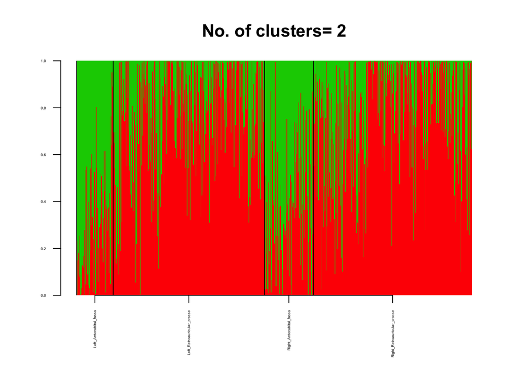

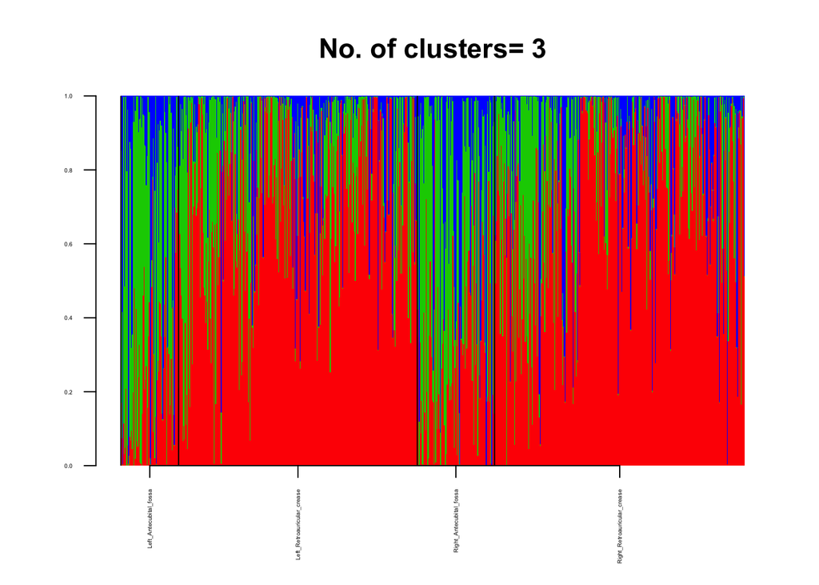

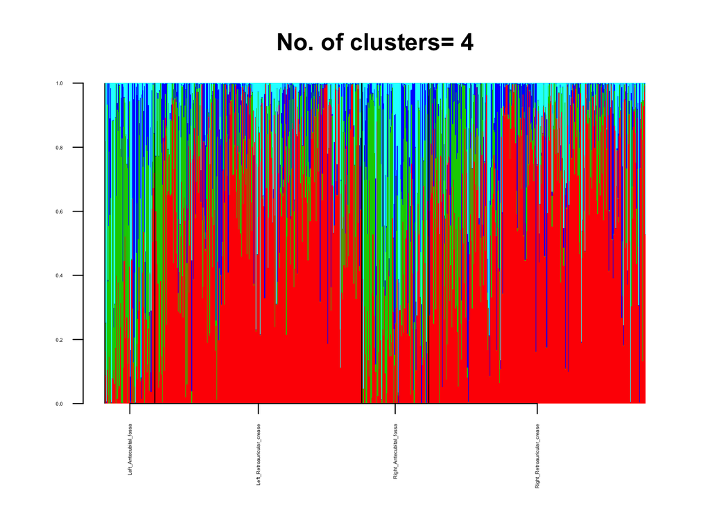

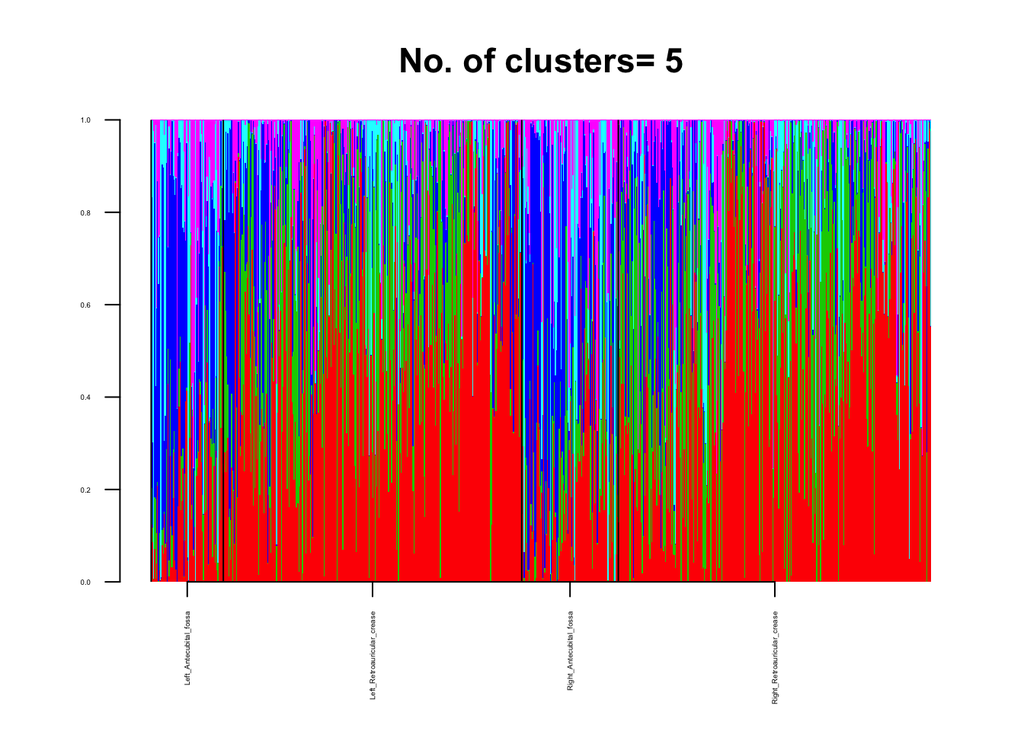

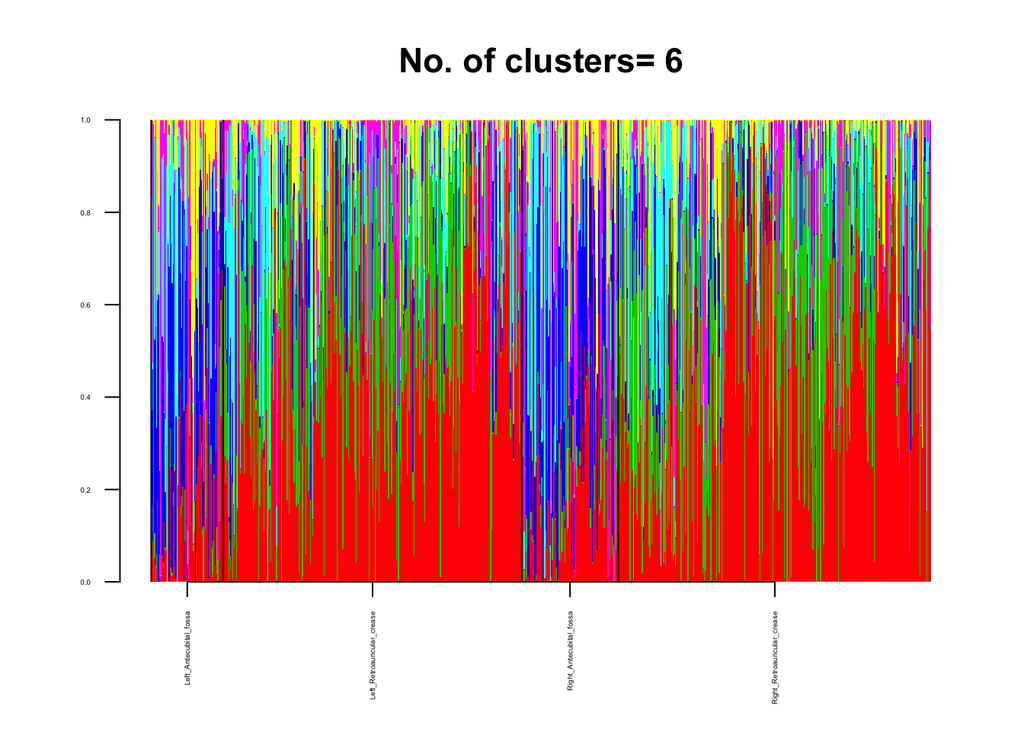

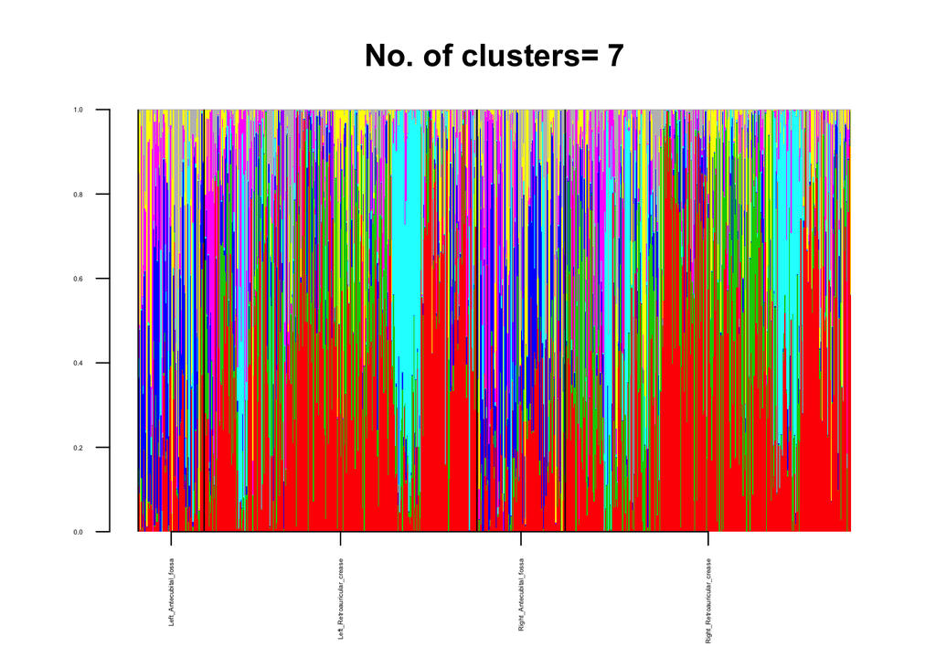

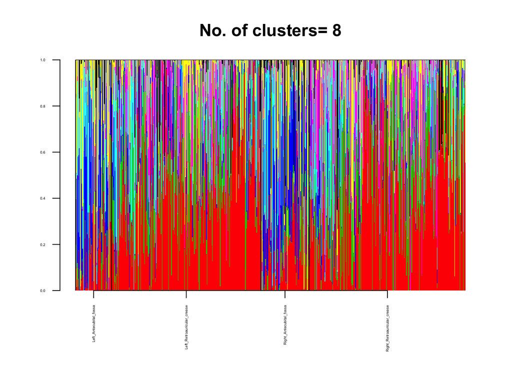

```
## [[1]]
## [1]  37.0 227.0 429.5 639.5
##
## [[2]]
## [1]  37.0 227.0 429.5 639.5
##
## [[3]]
## [1]  37.0 227.0 429.5 639.5
##
## [[4]]
## [1]  37.0 227.0 429.5 639.5
##
## [[5]]
## [1]  37.0 227.0 429.5 639.5
##
## [[6]]
## [1]  37.0 227.0 429.5 639.5
##
## [[7]]
## [1]  37.0 227.0 429.5 639.5
```

```r
lapply(2:8, function(n) structure_hands_metagenome(hands_data,type_handsite,n));
```

It seems that the clustering is mainly between the crease and fossa instead of being between the left hand and the right hand. We do a PC plot to see if this pattern shows up in the PCs. It does seem that crease and fossa do cluster sort of together.

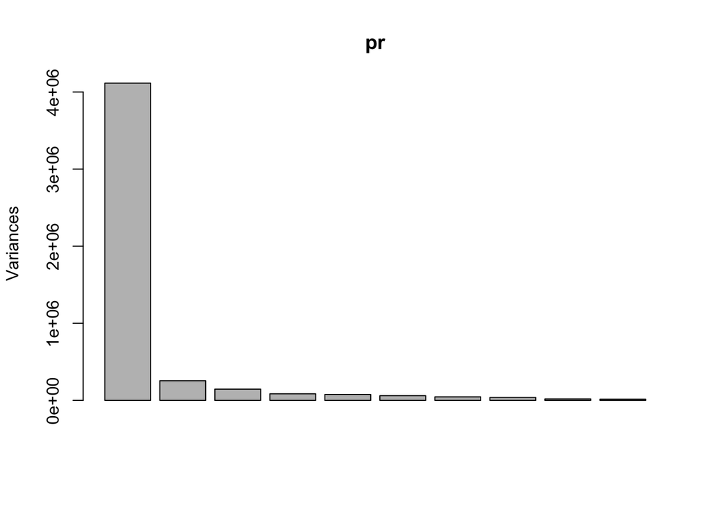

```r
pr <- prcomp(log(hands_data+0.5)%*%t(log(hands_data+0.5)));
plot(pr)
```

The plot of PC1 vs PC2 is as follows

```r
suppressWarnings(suppressMessages(iplot(pr$x[,1], pr$x[,2], as.numeric(as.factor(type_handsite)),type_handsite)))
```

[interactive chart not shown]

The plot of PC1 vs PC3 is as follows

```r
suppressWarnings(suppressMessages(iplot(pr$x[,1], pr$x[,3], as.numeric(as.factor(type_handsite)),type_handsite)))
```

[interactive chart not shown]

```r
K=8
docweights <- as.matrix(read.table(paste0('../internal_data/hands_data/hands_topics_omega_',K,'.txt')));
#tsne_samples <- tsne(docweights,2);
#write.table(tsne_samples,paste0('../internal_data/hands_data/tsne_samples_',K,'.txt'));
tsne_samples <- as.matrix(read.table(paste0('../internal_data/hands_data/tsne_samples_',K,'.txt')));
options(warn=-1)
suppressWarnings(suppressMessages(iplot(tsne_samples[,1],tsne_samples[,2], as.numeric(as.factor(type_handsite)),type_handsite)))
```

[interactive chart not shown]

## Clustering of the full data

We now consider the clustering of all the tissue samples together, not just Skin or crease/fossa. We check if the samples coming from other tissues lead to distinct clusters or not.

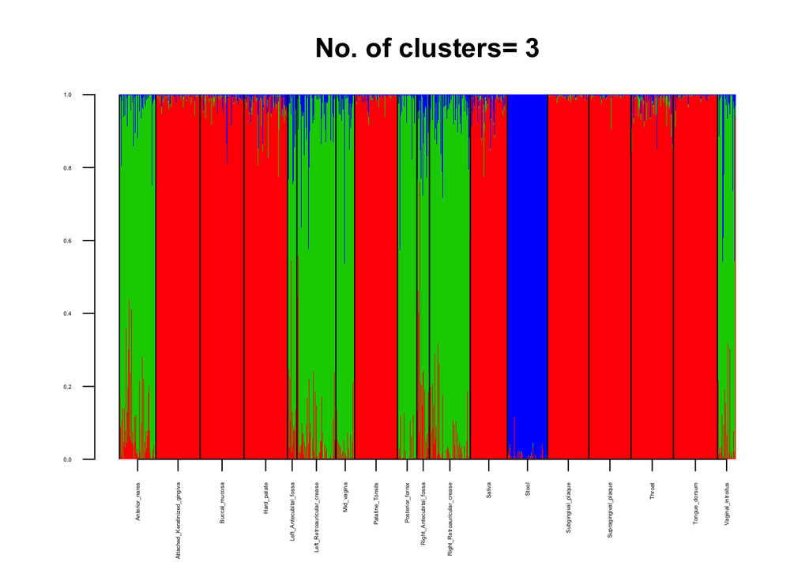

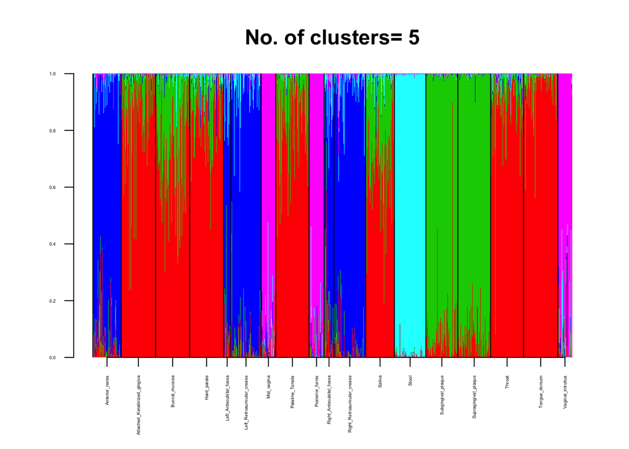

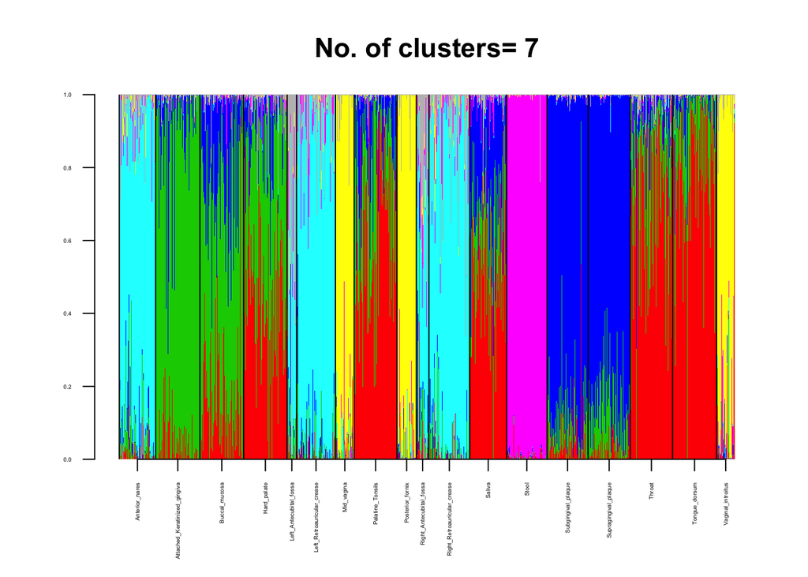

```
## [[1]]
##  [1]  143.0  460.0  806.0 1149.0 1357.0 1547.0 1773.5 2015.5 2260.0 2385.5
## [11] 2595.5 2901.0 3205.0 3525.5 3852.5 4184.5 4524.0 4769.0
##
## [[2]]
##  [1]  143.0  460.0  806.0 1149.0 1357.0 1547.0 1773.5 2015.5 2260.0 2385.5
## [11] 2595.5 2901.0 3205.0 3525.5 3852.5 4184.5 4524.0 4769.0
##
## [[3]]
##  [1]  143.0  460.0  806.0 1149.0 1357.0 1547.0 1773.5 2015.5 2260.0 2385.5
## [11] 2595.5 2901.0 3205.0 3525.5 3852.5 4184.5 4524.0 4769.0
```

```r
full_data <- mat_round;
metadata <- pData(hmp);
type_bodysite <- metadata$HMPbodysubsite;
structure_body_metagenome <- function(counts_data,type_info,K)
{
  counts_data <- counts_data[which(rowSums(counts_data)!=0),];
  type_info <- type_info[which(rowSums(counts_data)!=0)];
 # Topic_Clus <- topics(counts_data,K,tol=0.00005);
 #  write.table(Topic_Clus$omega,paste0('../internal_data/body_data/topics_omega_',K,'.txt'));
 #  write.table(Topic_Clus$theta,paste0('../internal_data/body_data/topics_theta_',K,'.txt'));
  docweights <- as.matrix(read.table(paste0('../internal_data/body_data/topics_omega_',K,'.txt')));

  type_ordered <- type_info[order(type_info)];
  docweights_ordered <- docweights[order(type_info),];
  barplot(t(docweights_ordered),col=2:(K+1),axisnames=F,space=0,border=NA,main=paste("No. of clusters=",K),las=1,ylim=c(0,1),cex.axis=0.3,cex.main=1.4);
  labels = match(unique(type_ordered), type_ordered);
  abline(v=labels-1)

  labels_low=labels-1;
  labels_up=c(labels_low[2:length(labels_low)],dim(docweights_ordered)[1]);
  mid_point <- labels_low +0.5*(labels_up-labels_low);
  axis(1,at=mid_point, unique(type_ordered),las=2,cex.axis=0.3);
}

lapply(c(3,5,7), function(n) structure_body_metagenome(full_data,type_bodysite,n));
```

It seems that for the full data case too, the left hand and right hand separation is not observed, but even the difference between crease and fossa is not clear when the entire data is taken into account, mainly the differences with the other tissues among themselves and with skin dominate the clusters.